# EFA CFA TR APSI YOUTH

Levi Brackman

26 January 2016

1. I have a definite sense of purpose in life.
2. I have a firm sense of who I am.
3. I have a set of basic beliefs and values that guide my actions and decisions.
4. I know what I want out of life.
5. I have a clear set of personal values or moral standards.
6. I don’t know where I fit in the world.
7. I have specific personal goals for the future.
8. I have a clear sense of who I want to be when I am an adult.

```r
##load packages
library(psych)
library(GPArotation)
library(plyr)
library(dplyr)
library(lavaan)
```

```r
library(semPlot)
# data preparation
data <- read.csv("~/Dropbox/Git/stats/allsurveysYT1_Jan2016.csv", header=T)
APSI<-select(data,  APSI_1,  APSI_2,  APSI_3,  APSI_4,  APSI_5,  APSI_6, APSI_7,  APSI_8)
APSI$APSI_6  <-  6- APSI$APSI_6
APSI<- data.frame(apply(APSI,2, as.numeric))
str(APSI)
```

```
## 'data.frame':    1288 obs. of  8 variables:
##  $ APSI_1: num  4 3 3 3 4 5 4 4 5 4 ...
##  $ APSI_2: num  4 2 3 4 4 1 4 2 5 4 ...
##  $ APSI_3: num  2 5 3 4 3 5 4 4 4 4 ...
##  $ APSI_4: num  3 4 3 3 3 5 4 4 5 4 ...
##  $ APSI_5: num  5 2 3 5 5 5 4 2 3 4 ...
##  $ APSI_6: num  4 3 3 2 4 3 2 2 5 2 ...
##  $ APSI_7: num  1 4 3 3 1 4 4 3 3 4 ...
##  $ APSI_8: num  3 1 3 3 2 5 4 3 3 4 ...
```

```r
colnames(APSI) <- c("1","2", "3", "4", "5", "6", "7", "8")
 APSI<- APSI[complete.cases(APSI[,]),]
```

## parallal analysis and scree plot

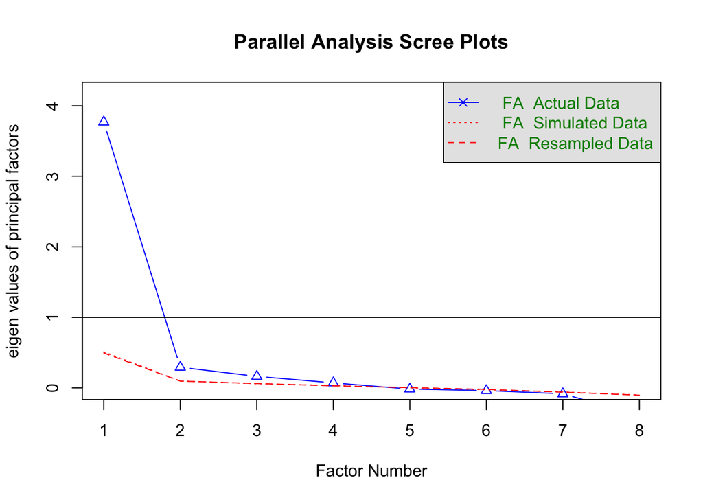

```
## Parallel analysis suggests that the number of factors =  4  and the number of components =  NA
```

```r
parallel<-fa.parallel(APSI, fm="ml",fa="fa")
```

```r
#one factors are greater than one Eigenvalue scree plot says there are two factors. Paralel analysis suggests 4 factors
#eigenvalues (kaiser)
parallel$fa.values
```

```
## [1]  3.77011103  0.29181257  0.16222252  0.07077554 -0.01726720 -0.03946750
## [7] -0.08504040 -0.38762185
```

```r
#over 1=1, over .7=0
```

# doing aprincipal components analysis to see how many factors there might be using that method

# Deal with NA doing principle componant analysis

```r
princomp(na.omit(APSI), cor = TRUE)
```

```
## Call:
## princomp(x = na.omit(APSI), cor = TRUE)
##
## Standard deviations:
##    Comp.1    Comp.2    Comp.3    Comp.4    Comp.5    Comp.6    Comp.7
## 2.0411640 1.1059534 0.8978297 0.7346805 0.5850569 0.5673847 0.5552584
##    Comp.8
## 0.5404942
##
##  8  variables and  935 observations.
```

```r
parallel2<-princomp(na.omit(APSI), cor = TRUE)
summary(parallel2)
```

```
## Importance of components:
##                           Comp.1    Comp.2    Comp.3     Comp.4     Comp.5
## Standard deviation     2.0411640 1.1059534 0.8978297 0.73468048 0.58505688
## Proportion of Variance 0.5207938 0.1528916 0.1007623 0.06746943 0.04278644
## Cumulative Proportion  0.5207938 0.6736854 0.7744477 0.84191713 0.88470358
##                            Comp.6     Comp.7     Comp.8
## Standard deviation     0.56738473 0.55525845 0.54049422
## Proportion of Variance 0.04024068 0.03853899 0.03651675
## Cumulative Proportion  0.92494426 0.96348325 1.00000000
```

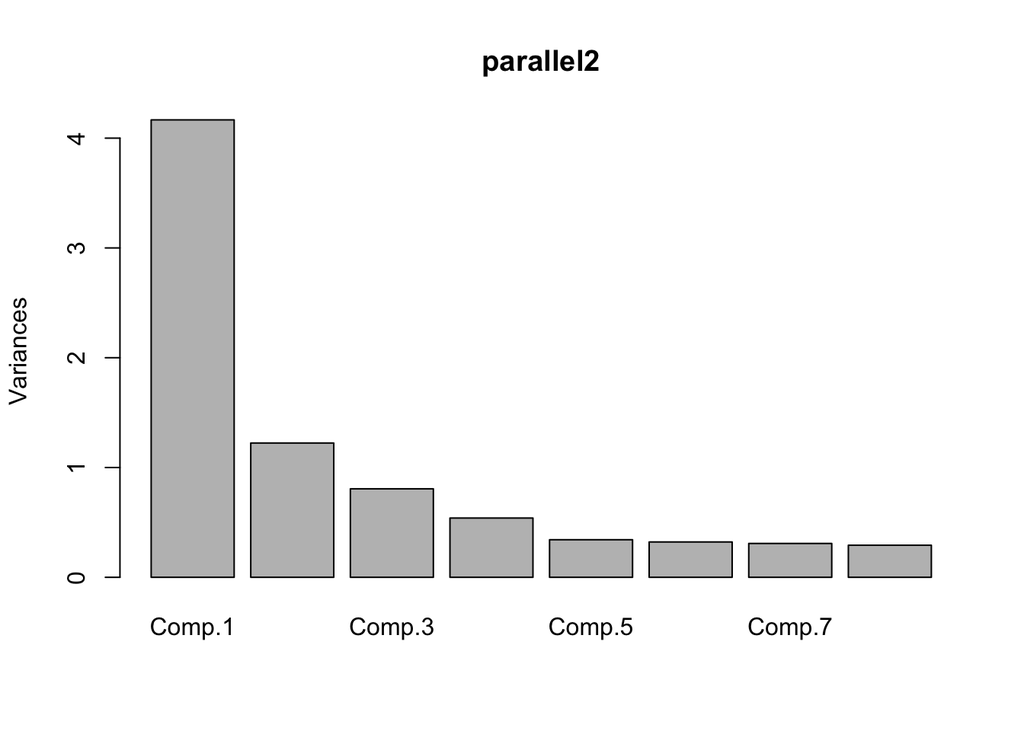

```r
plot(parallel2)##results show at least two factors
```

#simple structure

```r
twofactor<-fa(APSI, nfactors=2, rotate="oblimin", fm="ml")
twofactor#not a good fit
```

```
## Factor Analysis using method =  ml
## Call: fa(r = APSI, nfactors = 2, rotate = "oblimin", fm = "ml")
## Standardized loadings (pattern matrix) based upon correlation matrix
##     ML2   ML1    h2    u2 com
## 1  0.84 -0.03 0.693 0.307 1.0
## 2  0.77  0.01 0.592 0.408 1.0
## 3  0.00  1.00 0.995 0.005 1.0
## 4  0.83 -0.02 0.672 0.328 1.0
## 5  0.63  0.19 0.505 0.495 1.2
## 6 -0.13  0.29 0.081 0.919 1.4
## 7  0.76  0.03 0.599 0.401 1.0
## 8  0.82 -0.05 0.658 0.342 1.0
##
##                        ML2  ML1
## SS loadings           3.67 1.13
## Proportion Var        0.46 0.14
## Cumulative Var        0.46 0.60
## Proportion Explained  0.76 0.24
## Cumulative Proportion 0.76 1.00
##
##  With factor correlations of
##      ML2  ML1
## ML2 1.00 0.28
## ML1 0.28 1.00
##
## Mean item complexity =  1.1
## Test of the hypothesis that 2 factors are sufficient.
##
## The degrees of freedom for the null model are  28  and the objective function was  3.82 with Chi Square of  3551.2
## The degrees of freedom for the model are 13  and the objective function was  0.18
##
## The root mean square of the residuals (RMSR) is  0.04
## The df corrected root mean square of the residuals is  0.06
##
## The harmonic number of observations is  935 with the empirical chi square  87.21  with prob <  4.8e-13
## The total number of observations was  935  with MLE Chi Square =  164.1  with prob <  2.9e-28
##
## Tucker Lewis Index of factoring reliability =  0.907
## RMSEA index =  0.112  and the 90 % confidence intervals are  0.097 0.127
## BIC =  75.17
## Fit based upon off diagonal values = 0.99
## Measures of factor score adequacy
##                                                 ML2  ML1
## Correlation of scores with factors             0.95 1.00
## Multiple R square of scores with factors       0.91 0.99
## Minimum correlation of possible factor scores  0.82 0.99
```

```r
1-((twofactor$STATISTIC - twofactor$dof)/(twofactor$null.chisq- twofactor$null.dof))
```

```
## [1] 0.9571124
```

```r
threefactor<-fa(APSI, nfactors=3, rotate="oblimin", fm="ml")
threefactor#Still not a great fit. 1, 2, 4, 7, 8 are one factor 3 and 5 seem to be thir own factors and 6 crossloads on all factors.
```

```
## Factor Analysis using method =  ml
## Call: fa(r = APSI, nfactors = 3, rotate = "oblimin", fm = "ml")
## Standardized loadings (pattern matrix) based upon correlation matrix
##    ML3   ML1   ML2   h2    u2 com
## 1 0.77 -0.03  0.09 0.68 0.324 1.0
## 2 0.65  0.00  0.17 0.58 0.418 1.1
## 3 0.00  0.99  0.02 1.00 0.005 1.0
## 4 0.86  0.00 -0.04 0.69 0.308 1.0
## 5 0.03  0.03  0.96 0.98 0.019 1.0
## 6 0.09  0.35 -0.33 0.14 0.864 2.1
## 7 0.79  0.06 -0.04 0.62 0.383 1.0
## 8 0.85 -0.03 -0.04 0.67 0.326 1.0
##
##                        ML3  ML1  ML2
## SS loadings           3.16 1.09 1.10
## Proportion Var        0.39 0.14 0.14
## Cumulative Var        0.39 0.53 0.67
## Proportion Explained  0.59 0.20 0.21
## Cumulative Proportion 0.59 0.79 1.00
##
##  With factor correlations of
##      ML3  ML1  ML2
## ML3 1.00 0.26 0.65
## ML1 0.26 1.00 0.33
## ML2 0.65 0.33 1.00
##
## Mean item complexity =  1.2
## Test of the hypothesis that 3 factors are sufficient.
##
## The degrees of freedom for the null model are  28  and the objective function was  3.82 with Chi Square of  3551.2
## The degrees of freedom for the model are 7  and the objective function was  0.07
##
## The root mean square of the residuals (RMSR) is  0.02
## The df corrected root mean square of the residuals is  0.04
##
## The harmonic number of observations is  935 with the empirical chi square  26.21  with prob <  0.00046
## The total number of observations was  935  with MLE Chi Square =  67.93  with prob <  3.9e-12
##
## Tucker Lewis Index of factoring reliability =  0.931
## RMSEA index =  0.097  and the 90 % confidence intervals are  0.076 0.118
## BIC =  20.05
## Fit based upon off diagonal values = 1
## Measures of factor score adequacy
##                                                 ML3  ML1  ML2
## Correlation of scores with factors             0.95 1.00 0.99
## Multiple R square of scores with factors       0.91 0.99 0.98
## Minimum correlation of possible factor scores  0.82 0.99 0.96
```

```r
1-((threefactor$STATISTIC - threefactor$dof)/(threefactor$null.chisq- threefactor$null.dof))
```

```
## [1] 0.9827058
```

```r
fourfactor<-fa(APSI, nfactors=4, rotate="oblimin", fm="ml")
fourfactor#An over fit
```

```
## Factor Analysis using method =  ml
## Call: fa(r = APSI, nfactors = 4, rotate = "oblimin", fm = "ml")
## Standardized loadings (pattern matrix) based upon correlation matrix
##     ML2   ML4   ML1   ML3   h2    u2 com
## 1  0.31  0.59  0.02 -0.04 0.71 0.290 1.5
## 2  0.04  0.80  0.05 -0.01 0.69 0.310 1.0
## 3  0.05  0.01  0.12  0.70 0.56 0.435 1.1
## 4  0.67  0.20  0.04 -0.03 0.69 0.313 1.2
## 5  0.03  0.58 -0.18  0.34 0.64 0.362 1.8
## 6 -0.01  0.01  0.99  0.03 1.00 0.005 1.0
## 7  0.89 -0.10 -0.03  0.08 0.70 0.295 1.0
## 8  0.65  0.21  0.00 -0.05 0.67 0.329 1.2
##
##                        ML2  ML4  ML1  ML3
## SS loadings           2.11 1.81 1.04 0.69
## Proportion Var        0.26 0.23 0.13 0.09
## Cumulative Var        0.26 0.49 0.62 0.71
## Proportion Explained  0.37 0.32 0.18 0.12
## Cumulative Proportion 0.37 0.69 0.88 1.00
##
##  With factor correlations of
##       ML2   ML4   ML1  ML3
## ML2  1.00  0.80 -0.05 0.29
## ML4  0.80  1.00 -0.06 0.31
## ML1 -0.05 -0.06  1.00 0.17
## ML3  0.29  0.31  0.17 1.00
##
## Mean item complexity =  1.2
## Test of the hypothesis that 4 factors are sufficient.
##
## The degrees of freedom for the null model are  28  and the objective function was  3.82 with Chi Square of  3551.2
## The degrees of freedom for the model are 2  and the objective function was  0
##
## The root mean square of the residuals (RMSR) is  0
## The df corrected root mean square of the residuals is  0.01
##
## The harmonic number of observations is  935 with the empirical chi square  0.29  with prob <  0.86
## The total number of observations was  935  with MLE Chi Square =  1.46  with prob <  0.48
##
## Tucker Lewis Index of factoring reliability =  1.002
## RMSEA index =  0  and the 90 % confidence intervals are  NA 0.059
## BIC =  -12.22
## Fit based upon off diagonal values = 1
## Measures of factor score adequacy
##                                                 ML2  ML4  ML1  ML3
## Correlation of scores with factors             0.94 0.93 1.00 0.79
## Multiple R square of scores with factors       0.88 0.86 0.99 0.62
## Minimum correlation of possible factor scores  0.76 0.72 0.99 0.25
```

```r
1-((fourfactor$STATISTIC - fourfactor$dof)/(fourfactor$null.chisq- fourfactor$null.dof))
```

```
## [1] 1.000152
```

```r
fa2latex(fa(APSI,2, rotate="oblimin", fm="ml"),heading="Table 2. Factor Loadings for Exploratory Factor Analysis with Oblimin Rotation
of APSI")
```

```
## % Called in the psych package  fa2latex % Called in the psych package  fa(APSI, 2, rotate = "oblimin", fm = "ml") % Called in the psych package  Table 2. Factor Loadings for Exploratory Factor Analysis with Oblimin Rotation
## of APSI
## \begin{table}[htpb]\caption{fa2latex}
## \begin{center}
## \begin{scriptsize}
## \begin{tabular} {l r r r r r }
##  \multicolumn{ 5 }{l}{ Table 2. Factor Loadings for Exploratory Factor Analysis with Oblimin Rotation
## of APSI } \cr
##  \hline Variable  &   ML2  &  ML1  &  h2  &  u2  &  com \cr
##   \hline
## 1   &  \bf{ 0.84}  &  -0.03  &  0.69  &  0.31  &  1.00 \cr
##  2   &  \bf{ 0.77}  &   0.01  &  0.59  &  0.41  &  1.00 \cr
##  3   &   0.00  &  \bf{ 1.00}  &  1.00  &  0.00  &  1.00 \cr
##  4   &  \bf{ 0.83}  &  -0.02  &  0.67  &  0.33  &  1.00 \cr
##  5   &  \bf{ 0.63}  &   0.19  &  0.51  &  0.49  &  1.19 \cr
##  6   &  -0.13  &   0.29  &  0.08  &  0.92  &  1.39 \cr
##  7   &  \bf{ 0.76}  &   0.03  &  0.60  &  0.40  &  1.00 \cr
##  8   &  \bf{ 0.82}  &  -0.05  &  0.66  &  0.34  &  1.01 \cr
## \hline \cr SS loadings & 3.67 &  1.13 &  \cr
## \cr
##             \hline \cr
## ML2   & 1.00 & 0.28 \cr
##  ML1   & 0.28 & 1.00 \cr
##  \hline
## \end{tabular}
## \end{scriptsize}
## \end{center}
## \label{default}
## \end{table}
```

```r
fa2latex(fa(APSI,3, rotate="oblimin", fm="ml"),heading="Table 3. Factor Loadings for Exploratory Factor Analysis with Oblimin Rotation
of APSI")
```

```
## % Called in the psych package  fa2latex % Called in the psych package  fa(APSI, 3, rotate = "oblimin", fm = "ml") % Called in the psych package  Table 3. Factor Loadings for Exploratory Factor Analysis with Oblimin Rotation
## of APSI
## \begin{table}[htpb]\caption{fa2latex}
## \begin{center}
## \begin{scriptsize}
## \begin{tabular} {l r r r r r r }
##  \multicolumn{ 6 }{l}{ Table 3. Factor Loadings for Exploratory Factor Analysis with Oblimin Rotation
## of APSI } \cr
##  \hline Variable  &   ML3  &  ML1  &  ML2  &  h2  &  u2  &  com \cr
##   \hline
## 1   &  \bf{0.77}  &  -0.03  &   0.09  &  0.68  &  0.32  &  1.03 \cr
##  2   &  \bf{0.65}  &   0.00  &   0.17  &  0.58  &  0.42  &  1.13 \cr
##  3   &  0.00  &  \bf{ 0.99}  &   0.02  &  1.00  &  0.00  &  1.00 \cr
##  4   &  \bf{0.86}  &   0.00  &  -0.04  &  0.69  &  0.31  &  1.00 \cr
##  5   &  0.03  &   0.03  &  \bf{ 0.96}  &  0.98  &  0.02  &  1.00 \cr
##  6   &  0.09  &  \bf{ 0.35}  &  \bf{-0.33}  &  0.14  &  0.86  &  2.14 \cr
##  7   &  \bf{0.79}  &   0.06  &  -0.04  &  0.62  &  0.38  &  1.02 \cr
##  8   &  \bf{0.85}  &  -0.03  &  -0.04  &  0.67  &  0.33  &  1.01 \cr
## \hline \cr SS loadings & 3.16 &  1.09 &  1.1 &  \cr
## \cr
##             \hline \cr
## ML3   & 1.00 & 0.26 & 0.65 \cr
##  ML1   & 0.26 & 1.00 & 0.33 \cr
##  ML2   & 0.65 & 0.33 & 1.00 \cr
##  \hline
## \end{tabular}
## \end{scriptsize}
## \end{center}
## \label{default}
## \end{table}
```

```r
fa2latex(fa(APSI,4, rotate="oblimin", fm="ml"),heading="Table 4. Factor Loadings for Exploratory Factor Analysis with Oblimin Rotation
of APSI")
```

```
## % Called in the psych package  fa2latex % Called in the psych package  fa(APSI, 4, rotate = "oblimin", fm = "ml") % Called in the psych package  Table 4. Factor Loadings for Exploratory Factor Analysis with Oblimin Rotation
## of APSI
## \begin{table}[htpb]\caption{fa2latex}
## \begin{center}
## \begin{scriptsize}
## \begin{tabular} {l r r r r r r r }
##  \multicolumn{ 7 }{l}{ Table 4. Factor Loadings for Exploratory Factor Analysis with Oblimin Rotation
## of APSI } \cr
##  \hline Variable  &   ML2  &  ML4  &  ML1  &  ML3  &  h2  &  u2  &  com \cr
##   \hline
## 1   &  \bf{ 0.31}  &  \bf{ 0.59}  &   0.02  &  -0.04  &  0.71  &  0.29  &  1.52 \cr
##  2   &   0.04  &  \bf{ 0.80}  &   0.05  &  -0.01  &  0.69  &  0.31  &  1.01 \cr
##  3   &   0.05  &   0.01  &   0.12  &  \bf{ 0.70}  &  0.56  &  0.44  &  1.07 \cr
##  4   &  \bf{ 0.67}  &   0.20  &   0.04  &  -0.03  &  0.69  &  0.31  &  1.20 \cr
##  5   &   0.03  &  \bf{ 0.58}  &  -0.18  &  \bf{ 0.34}  &  0.64  &  0.36  &  1.84 \cr
##  6   &  -0.01  &   0.01  &  \bf{ 0.99}  &   0.03  &  1.00  &  0.00  &  1.00 \cr
##  7   &  \bf{ 0.89}  &  -0.10  &  -0.03  &   0.08  &  0.70  &  0.30  &  1.04 \cr
##  8   &  \bf{ 0.65}  &   0.21  &   0.00  &  -0.05  &  0.67  &  0.33  &  1.22 \cr
## \hline \cr SS loadings & 2.11 &  1.81 &  1.04 &  0.69 &  \cr
## \cr
##             \hline \cr
## ML2   &  1.00 &  0.80 & -0.05 &  0.29 \cr
##  ML4   &  0.80 &  1.00 & -0.06 &  0.31 \cr
##  ML1   & -0.05 & -0.06 &  1.00 &  0.17 \cr
##  ML3   &  0.29 &  0.31 &  0.17 &  1.00 \cr
##  \hline
## \end{tabular}
## \end{scriptsize}
## \end{center}
## \label{default}
## \end{table}
```

# question 1,4,7,8 seem to talk about purpose. so try as one factr

```r
 APSI12478<-select(APSI, 1, 2, 4,7,8)
 APSI12478<-tbl_df(APSI12478)
  APSI12478
```

```
## Source: local data frame [935 x 5]
##
##        1     2     4     7     8
##    (dbl) (dbl) (dbl) (dbl) (dbl)
## 1      4     4     3     1     3
## 2      3     2     4     4     1
## 3      3     3     3     3     3
## 4      3     4     3     3     3
## 5      4     4     3     1     2
## 6      5     1     5     4     5
## 7      4     4     4     4     4
## 8      4     2     4     3     3
## 9      5     5     5     3     3
## 10     4     4     4     4     4
## ..   ...   ...   ...   ...   ...
```

```r
twofactorAPSI12478<-fa(APSI12478, nfactors=1, rotate="varimax", fm="ml")
twofactorAPSI12478#The TLI is good but the RMSEA is a poor fit
```

```
## Factor Analysis using method =  ml
## Call: fa(r = APSI12478, nfactors = 1, rotate = "varimax", fm = "ml")
## Standardized loadings (pattern matrix) based upon correlation matrix
##    ML1   h2   u2 com
## 1 0.82 0.68 0.32   1
## 2 0.75 0.57 0.43   1
## 4 0.83 0.69 0.31   1
## 7 0.78 0.61 0.39   1
## 8 0.82 0.67 0.33   1
##
##                 ML1
## SS loadings    3.21
## Proportion Var 0.64
##
## Mean item complexity =  1
## Test of the hypothesis that 1 factor is sufficient.
##
## The degrees of freedom for the null model are  10  and the objective function was  2.92 with Chi Square of  2723.2
## The degrees of freedom for the model are 5  and the objective function was  0.07
##
## The root mean square of the residuals (RMSR) is  0.03
## The df corrected root mean square of the residuals is  0.04
##
## The harmonic number of observations is  935 with the empirical chi square  18.1  with prob <  0.0028
## The total number of observations was  935  with MLE Chi Square =  60.83  with prob <  8.2e-12
##
## Tucker Lewis Index of factoring reliability =  0.959
## RMSEA index =  0.11  and the 90 % confidence intervals are  0.086 0.135
## BIC =  26.63
## Fit based upon off diagonal values = 1
## Measures of factor score adequacy
##                                                 ML1
## Correlation of scores with factors             0.95
## Multiple R square of scores with factors       0.90
## Minimum correlation of possible factor scores  0.80
```

```r
fa2latex(fa(APSI12478,1, rotate="oblimin", fm="ml"),heading="Table 5. Factor Loadings for Exploratory Factor Analysis with Oblimin Rotation
of APSI")
```

```
## % Called in the psych package  fa2latex % Called in the psych package  fa(APSI12478, 1, rotate = "oblimin", fm = "ml") % Called in the psych package  Table 5. Factor Loadings for Exploratory Factor Analysis with Oblimin Rotation
## of APSI
## \begin{table}[htpb]\caption{fa2latex}
## \begin{center}
## \begin{scriptsize}
## \begin{tabular} {l r r r r }
##  \multicolumn{ 4 }{l}{ Table 5. Factor Loadings for Exploratory Factor Analysis with Oblimin Rotation
## of APSI } \cr
##  \hline Variable  &   ML1  &  ML1.1  &  ML1.2  &  com \cr
##   \hline
## 1   &  \bf{0.82}  &  0.68  &  0.32  &  1 \cr
##  2   &  \bf{0.75}  &  0.57  &  0.43  &  1 \cr
##  4   &  \bf{0.83}  &  0.69  &  0.31  &  1 \cr
##  7   &  \bf{0.78}  &  0.61  &  0.39  &  1 \cr
##  8   &  \bf{0.82}  &  0.67  &  0.33  &  1 \cr
## \hline \cr SS loadings & 3.21 &  \cr
##  \hline
## \end{tabular}
## \end{scriptsize}
## \end{center}
## \label{default}
## \end{table}
```

```r
#CFI
1-((twofactorAPSI12478$STATISTIC - twofactorAPSI12478$dof)/(twofactorAPSI12478$null.chisq- twofactorAPSI12478$null.dof))
```

```
## [1] 0.9794236
```

# question 1,4,7,8 seem to talk about purpose. so try as one factr

```r
 APSI124578<-select(APSI, 1, 2, 4,5, 7,8)
APSI124578<-tbl_df(APSI124578)
APSI124578
```

```
## Source: local data frame [935 x 6]
##
##        1     2     4     5     7     8
##    (dbl) (dbl) (dbl) (dbl) (dbl) (dbl)
## 1      4     4     3     5     1     3
## 2      3     2     4     2     4     1
## 3      3     3     3     3     3     3
## 4      3     4     3     5     3     3
## 5      4     4     3     5     1     2
## 6      5     1     5     5     4     5
## 7      4     4     4     4     4     4
## 8      4     2     4     2     3     3
## 9      5     5     5     3     3     3
## 10     4     4     4     4     4     4
## ..   ...   ...   ...   ...   ...   ...
```

```r
twofactorAPSI124578<-fa(APSI124578, nfactors=1, rotate="varimax", fm="ml")
twofactorAPSI124578#The TLI is good but the RMSEA is a poor fit
```

```
## Factor Analysis using method =  ml
## Call: fa(r = APSI124578, nfactors = 1, rotate = "varimax", fm = "ml")
## Standardized loadings (pattern matrix) based upon correlation matrix
##    ML1   h2   u2 com
## 1 0.83 0.69 0.31   1
## 2 0.77 0.59 0.41   1
## 4 0.82 0.67 0.33   1
## 5 0.68 0.46 0.54   1
## 7 0.77 0.60 0.40   1
## 8 0.81 0.65 0.35   1
##
##                 ML1
## SS loadings    3.67
## Proportion Var 0.61
##
## Mean item complexity =  1
## Test of the hypothesis that 1 factor is sufficient.
##
## The degrees of freedom for the null model are  15  and the objective function was  3.49 with Chi Square of  3253.94
## The degrees of freedom for the model are 9  and the objective function was  0.1
##
## The root mean square of the residuals (RMSR) is  0.03
## The df corrected root mean square of the residuals is  0.04
##
## The harmonic number of observations is  935 with the empirical chi square  33.24  with prob <  0.00012
## The total number of observations was  935  with MLE Chi Square =  93.46  with prob <  3.3e-16
##
## Tucker Lewis Index of factoring reliability =  0.957
## RMSEA index =  0.1  and the 90 % confidence intervals are  0.082 0.119
## BIC =  31.9
## Fit based upon off diagonal values = 1
## Measures of factor score adequacy
##                                                 ML1
## Correlation of scores with factors             0.95
## Multiple R square of scores with factors       0.91
## Minimum correlation of possible factor scores  0.82
```

```r
fa2latex(fa(APSI124578,1, rotate="oblimin", fm="ml"),heading="Table 5. Factor Loadings for Exploratory Factor Analysis with Oblimin Rotation
of APSI")
```

```
## % Called in the psych package  fa2latex % Called in the psych package  fa(APSI124578, 1, rotate = "oblimin", fm = "ml") % Called in the psych package  Table 5. Factor Loadings for Exploratory Factor Analysis with Oblimin Rotation
## of APSI
## \begin{table}[htpb]\caption{fa2latex}
## \begin{center}
## \begin{scriptsize}
## \begin{tabular} {l r r r r }
##  \multicolumn{ 4 }{l}{ Table 5. Factor Loadings for Exploratory Factor Analysis with Oblimin Rotation
## of APSI } \cr
##  \hline Variable  &   ML1  &  ML1.1  &  ML1.2  &  com \cr
##   \hline
## 1   &  \bf{0.83}  &  0.69  &  0.31  &  1 \cr
##  2   &  \bf{0.77}  &  0.59  &  0.41  &  1 \cr
##  4   &  \bf{0.82}  &  0.67  &  0.33  &  1 \cr
##  5   &  \bf{0.68}  &  0.46  &  0.54  &  1 \cr
##  7   &  \bf{0.77}  &  0.60  &  0.40  &  1 \cr
##  8   &  \bf{0.81}  &  0.65  &  0.35  &  1 \cr
## \hline \cr SS loadings & 3.67 &  \cr
##  \hline
## \end{tabular}
## \end{scriptsize}
## \end{center}
## \label{default}
## \end{table}
```

```r
#CFI
1-((twofactorAPSI124578$STATISTIC - twofactorAPSI124578$dof)/(twofactorAPSI124578$null.chisq- twofactorAPSI124578$null.dof))
```

```
## [1] 0.9739223
```

# drop question 2 and only uuse question 1,4,7,8 seem to talk about purpose. so try as one factr

```r
 APSI1478<-select(APSI, 1, 4,7,8)
 APSI1478<-tbl_df(APSI1478)
  APSI1478
```

```
## Source: local data frame [935 x 4]
##
##        1     4     7     8
##    (dbl) (dbl) (dbl) (dbl)
## 1      4     3     1     3
## 2      3     4     4     1
## 3      3     3     3     3
## 4      3     3     3     3
## 5      4     3     1     2
## 6      5     5     4     5
## 7      4     4     4     4
## 8      4     4     3     3
## 9      5     5     3     3
## 10     4     4     4     4
## ..   ...   ...   ...   ...
```

```r
twofactorAPSI1478<-fa(APSI1478, nfactors=1, rotate="varimax", fm="ml")
fa2latex(fa(APSI1478,1, rotate="oblimin", fm="ml"),heading="Table 6. Factor Loadings for Exploratory Factor Analysis with Oblimin Rotation
of APSI")
```

```
## % Called in the psych package  fa2latex % Called in the psych package  fa(APSI1478, 1, rotate = "oblimin", fm = "ml") % Called in the psych package  Table 6. Factor Loadings for Exploratory Factor Analysis with Oblimin Rotation
## of APSI
## \begin{table}[htpb]\caption{fa2latex}
## \begin{center}
## \begin{scriptsize}
## \begin{tabular} {l r r r r }
##  \multicolumn{ 4 }{l}{ Table 6. Factor Loadings for Exploratory Factor Analysis with Oblimin Rotation
## of APSI } \cr
##  \hline Variable  &   ML1  &  ML1.1  &  ML1.2  &  com \cr
##   \hline
## 1   &  \bf{0.79}  &  0.63  &  0.37  &  1 \cr
##  4   &  \bf{0.84}  &  0.70  &  0.30  &  1 \cr
##  7   &  \bf{0.80}  &  0.64  &  0.36  &  1 \cr
##  8   &  \bf{0.82}  &  0.68  &  0.32  &  1 \cr
## \hline \cr SS loadings & 2.65 &  \cr
##  \hline
## \end{tabular}
## \end{scriptsize}
## \end{center}
## \label{default}
## \end{table}
```

```r
twofactorAPSI1478#clearly shows that this is all one factor. Droping 2 makes it a much better fit.
```

```
## Factor Analysis using method =  ml
## Call: fa(r = APSI1478, nfactors = 1, rotate = "varimax", fm = "ml")
## Standardized loadings (pattern matrix) based upon correlation matrix
##    ML1   h2   u2 com
## 1 0.79 0.63 0.37   1
## 4 0.84 0.70 0.30   1
## 7 0.80 0.64 0.36   1
## 8 0.82 0.68 0.32   1
##
##                 ML1
## SS loadings    2.65
## Proportion Var 0.66
##
## Mean item complexity =  1
## Test of the hypothesis that 1 factor is sufficient.
##
## The degrees of freedom for the null model are  6  and the objective function was  2.17 with Chi Square of  2020.17
## The degrees of freedom for the model are 2  and the objective function was  0
##
## The root mean square of the residuals (RMSR) is  0.01
## The df corrected root mean square of the residuals is  0.02
##
## The harmonic number of observations is  935 with the empirical chi square  0.96  with prob <  0.62
## The total number of observations was  935  with MLE Chi Square =  4.18  with prob <  0.12
##
## Tucker Lewis Index of factoring reliability =  0.997
## RMSEA index =  0.034  and the 90 % confidence intervals are  NA 0.081
## BIC =  -9.5
## Fit based upon off diagonal values = 1
## Measures of factor score adequacy
##                                                 ML1
## Correlation of scores with factors             0.94
## Multiple R square of scores with factors       0.89
## Minimum correlation of possible factor scores  0.78
```

```r
#CFI
1-((twofactorAPSI1478$STATISTIC - twofactor$dof)/(twofactor$null.chisq- twofactor$null.dof))
```

```
## [1] 1.002503
```

# question 6 is negative but talks about fit in the world, question 2 talks about know “who I am” see if fits into one factor

```r
 APSI26<-select(APSI, 3, 5,6)
 APSI26<-tbl_df(APSI26)
 APSI26
```

```
## Source: local data frame [935 x 3]
##
##        3     5     6
##    (dbl) (dbl) (dbl)
## 1      2     5     4
## 2      5     2     3
## 3      3     3     3
## 4      4     5     2
## 5      3     5     4
## 6      5     5     3
## 7      4     4     2
## 8      4     2     2
## 9      4     3     5
## 10     4     4     2
## ..   ...   ...   ...
```

```r
twofactorAPSI26<-fa(APSI26, nfactors=3, rotate="varimax", fm="ml")
fa2latex(fa(APSI26,3, rotate="oblimin", fm="ml"),heading="Table 7. Factor Loadings for Exploratory Factor Analysis with Oblimin Rotation
of APSI")
```

```
## % Called in the psych package  fa2latex % Called in the psych package  fa(APSI26, 3, rotate = "oblimin", fm = "ml") % Called in the psych package  Table 7. Factor Loadings for Exploratory Factor Analysis with Oblimin Rotation
## of APSI
## \begin{table}[htpb]\caption{fa2latex}
## \begin{center}
## \begin{scriptsize}
## \begin{tabular} {l r r r r r r }
##  \multicolumn{ 6 }{l}{ Table 7. Factor Loadings for Exploratory Factor Analysis with Oblimin Rotation
## of APSI } \cr
##  \hline Variable  &   ML1  &  ML2  &  ML3  &  h2  &  u2  &  com \cr
##   \hline
## 3   &  \bf{ 0.51}  &   0.23  &  0  &  0.36  &  0.64  &  1.39 \cr
##  5   &  \bf{ 0.56}  &  -0.16  &  0  &  0.31  &  0.69  &  1.16 \cr
##  6   &  -0.01  &  \bf{ 0.48}  &  0  &  0.23  &  0.77  &  1.00 \cr
## \hline \cr SS loadings & 0.58 &  0.31 &  0 &  \cr
## \cr
##             \hline \cr
## ML1   & 1.00 & 0.16 & 0.00 \cr
##  ML2   & 0.16 & 1.00 & 0.00 \cr
##  ML3   & 0.00 & 0.00 & 1.00 \cr
##  \hline
## \end{tabular}
## \end{scriptsize}
## \end{center}
## \label{default}
## \end{table}
```

```r
twofactorAPSI26#seems to be a good fit
```

```
## Factor Analysis using method =  ml
## Call: fa(r = APSI26, nfactors = 3, rotate = "varimax", fm = "ml")
## Standardized loadings (pattern matrix) based upon correlation matrix
##    ML1   ML2 ML3   h2   u2 com
## 3 0.52  0.30   0 0.36 0.64 1.6
## 5 0.55 -0.09   0 0.31 0.69 1.0
## 6 0.01  0.47   0 0.23 0.77 1.0
##
##                        ML1  ML2 ML3
## SS loadings           0.57 0.32 0.0
## Proportion Var        0.19 0.11 0.0
## Cumulative Var        0.19 0.30 0.3
## Proportion Explained  0.64 0.36 0.0
## Cumulative Proportion 0.64 1.00 1.0
##
## Mean item complexity =  1.2
## Test of the hypothesis that 3 factors are sufficient.
##
## The degrees of freedom for the null model are  3  and the objective function was  0.29 with Chi Square of  270.14
## The degrees of freedom for the model are -3  and the objective function was  0.07
##
## The root mean square of the residuals (RMSR) is  0.11
## The df corrected root mean square of the residuals is  NA
##
## The harmonic number of observations is  935 with the empirical chi square  66.89  with prob <  NA
## The total number of observations was  935  with MLE Chi Square =  65.94  with prob <  NA
##
## Tucker Lewis Index of factoring reliability =  1.259
## Fit based upon off diagonal values = 0.84
## Measures of factor score adequacy
##                                                  ML1   ML2 ML3
## Correlation of scores with factors              0.65  0.52   0
## Multiple R square of scores with factors        0.42  0.27   0
## Minimum correlation of possible factor scores  -0.16 -0.46  -1
```

```r
#CFI
1-((twofactorAPSI26$STATISTIC - twofactor$dof)/(twofactor$null.chisq- twofactor$null.dof))
```

```
## [1] 0.9849735
```

# question three and five talk about morals and values and could be one factor

```r
 APSI35<-select(APSI, 3,5)
 APSI35<-tbl_df(APSI35)
 APSI35
```

```
## Source: local data frame [935 x 2]
##
##        3     5
##    (dbl) (dbl)
## 1      2     5
## 2      5     2
## 3      3     3
## 4      4     5
## 5      3     5
## 6      5     5
## 7      4     4
## 8      4     2
## 9      4     3
## 10     4     4
## ..   ...   ...
```

```r
twofactorAPSI35<-fa(APSI35, nfactors=1, rotate="varimax", fm="ml")
fa2latex(fa(APSI35,1, rotate="oblimin", fm="ml"),heading="Table 8. Factor Loadings for Exploratory Factor Analysis with Oblimin Rotation
of APSI")
```

```
## % Called in the psych package  fa2latex % Called in the psych package  fa(APSI35, 1, rotate = "oblimin", fm = "ml") % Called in the psych package  Table 8. Factor Loadings for Exploratory Factor Analysis with Oblimin Rotation
## of APSI
## \begin{table}[htpb]\caption{fa2latex}
## \begin{center}
## \begin{scriptsize}
## \begin{tabular} {l r r r r }
##  \multicolumn{ 4 }{l}{ Table 8. Factor Loadings for Exploratory Factor Analysis with Oblimin Rotation
## of APSI } \cr
##  \hline Variable  &   ML1  &  ML1.1  &  ML1.2  &  com \cr
##   \hline
## 3   &  \bf{0.61}  &  0.38  &  0.62  &  1 \cr
##  5   &  \bf{0.61}  &  0.38  &  0.62  &  1 \cr
## \hline \cr SS loadings & 0.75 &  \cr
##  \hline
## \end{tabular}
## \end{scriptsize}
## \end{center}
## \label{default}
## \end{table}
```

```r
twofactorAPSI35#seems to load well on one factor
```

```
## Factor Analysis using method =  ml
## Call: fa(r = APSI35, nfactors = 1, rotate = "varimax", fm = "ml")
## Standardized loadings (pattern matrix) based upon correlation matrix
##    ML1   h2   u2 com
## 3 0.61 0.38 0.62   1
## 5 0.61 0.38 0.62   1
##
##                 ML1
## SS loadings    0.75
## Proportion Var 0.38
##
## Mean item complexity =  1
## Test of the hypothesis that 1 factor is sufficient.
##
## The degrees of freedom for the null model are  1  and the objective function was  0.15 with Chi Square of  141.92
## The degrees of freedom for the model are -1  and the objective function was  0
##
## The root mean square of the residuals (RMSR) is  0
## The df corrected root mean square of the residuals is  NA
##
## The harmonic number of observations is  935 with the empirical chi square  0  with prob <  NA
## The total number of observations was  935  with MLE Chi Square =  0  with prob <  NA
##
## Tucker Lewis Index of factoring reliability =  1.007
## Fit based upon off diagonal values = 1
## Measures of factor score adequacy
##                                                 ML1
## Correlation of scores with factors             0.74
## Multiple R square of scores with factors       0.55
## Minimum correlation of possible factor scores  0.09
```

```r
#CFI
1-((twofactorAPSI35$STATISTIC - twofactor$dof)/(twofactor$null.chisq- twofactor$null.dof))
```

```
## [1] 1.00369
```

```r
#What are the factors
#Factor 1 (questions 1, 4, 7, 8) is purpose
#Factor 2 (questions 3,5) is moral values
#Factor 3 (questions 2,6) fit in the world, knowledge of who I am
```

# Finding Alpha

```r
alpha(APSI, na.rm = TRUE, check.keys=TRUE)
```

```
##
## Reliability analysis
## Call: alpha(x = APSI, na.rm = TRUE, check.keys = TRUE)
##
##   raw_alpha std.alpha G6(smc) average_r S/N   ase mean   sd
##       0.82      0.83    0.86      0.38 4.9 0.015  3.7 0.78
##
##  lower alpha upper     95% confidence boundaries
## 0.79 0.82 0.85
##
##  Reliability if an item is dropped:
##    raw_alpha std.alpha G6(smc) average_r S/N alpha se
## 1       0.77      0.78    0.82      0.34 3.6    0.018
## 2       0.78      0.79    0.83      0.35 3.8    0.017
## 3       0.84      0.85    0.86      0.45 5.7    0.015
## 4       0.77      0.79    0.82      0.34 3.7    0.018
## 5       0.78      0.79    0.82      0.35 3.8    0.017
## 6-      0.88      0.88    0.88      0.51 7.1    0.013
## 7       0.78      0.79    0.82      0.35 3.7    0.018
## 8       0.77      0.79    0.82      0.35 3.7    0.018
##
##  Item statistics
##      n raw.r std.r r.cor r.drop mean  sd
## 1  935  0.83  0.82 0.815 0.7454  3.7 1.2
## 2  935  0.78  0.79 0.762 0.6927  3.9 1.1
## 3  935  0.37  0.41 0.292 0.2226  3.9 1.0
## 4  935  0.81  0.81 0.796 0.7262  3.8 1.2
## 5  935  0.77  0.78 0.750 0.6909  4.1 1.0
## 6- 935  0.23  0.19 0.032 0.0075  2.9 1.4
## 7  935  0.79  0.80 0.773 0.7105  3.9 1.1
## 8  935  0.81  0.81 0.791 0.7257  3.8 1.2
```

# Create dataset for Target rotation

```r
data <- read.csv("~/Dropbox/Git/stats/allsurveysYT1_Jan2016.csv", header=T)
 APSI<-select(data,  APSI_1, APSI_2, APSI_4, APSI_7,  APSI_8,    APSI_5, APSI_3,  APSI_6)
APSI$APSI_6  <-  6- APSI$APSI_6
APSI<- data.frame(apply(APSI,2, as.numeric))
```

Load packedges

```r
library(GPArotation)
library(psych)
library(dplyr)

colnames(APSI) <- c("1","2", "3", "4", "5", "6", "7", "8")
```

Trying to see whether we can make this into two factors

```r
Targ_key <- make.keys(8,list(f1=1:5,f2=6:8))
Targ_key <- scrub(Targ_key,isvalue=1)  #fix the 0s, allow the NAs to be estimated
Targ_key <- list(Targ_key)
APSI_cor <- corFiml(APSI)
APSI_cor
```

```
##            1           2            3           4           5          6
## 1  1.0000000 0.686248357  0.673436529  0.61974433  0.65566219  0.5881005
## 2  0.6862484 1.000000000  0.607086624  0.53734103  0.61062409  0.5897553
## 3  0.6734365 0.607086624  1.000000000  0.67374287  0.67843958  0.5287717
## 4  0.6197443 0.537341028  0.673742874  1.00000000  0.66683390  0.5067699
## 5  0.6556622 0.610624090  0.678439576  0.66683390  1.00000000  0.5170080
## 6  0.5881005 0.589755314  0.528771683  0.50676991  0.51700800  1.0000000
## 7  0.2097511 0.228294887  0.215075960  0.25476260  0.18767318  0.3757412
## 8 -0.0277245 0.004749543 -0.005183542 -0.05011696 -0.05137862 -0.1385015
##           7            8
## 1 0.2097511 -0.027724499
## 2 0.2282949  0.004749543
## 3 0.2150760 -0.005183542
## 4 0.2547626 -0.050116959
## 5 0.1876732 -0.051378619
## 6 0.3757412 -0.138501481
## 7 1.0000000  0.254435806
## 8 0.2544358  1.000000000
```

```r
out_targetQ <- fa(APSI_cor,2,rotate="TargetQ",n.obs = 807,Target=Targ_key) #TargetT for orthogonal rotation
out_targetQ[c("loadings", "score.cor", "TLI", "RMSEA")]
```

```
## $loadings
##
## Loadings:
##   MR1    MR2
## 1  0.828
## 2  0.752
## 3  0.812
## 4  0.745
## 5  0.813
## 6  0.600  0.235
## 7         1.023
## 8 -0.157  0.293
##
##                  MR1   MR2
## SS loadings    3.518 1.197
## Proportion Var 0.440 0.150
## Cumulative Var 0.440 0.589
##
## $score.cor
##           [,1]      [,2]
## [1,] 1.0000000 0.1541564
## [2,] 0.1541564 1.0000000
##
## $TLI
## [1] 0.9086486
##
## $RMSEA
##      RMSEA      lower      upper confidence
## 0.11110701 0.09462461 0.12748972 0.10000000
```

```r
fa2latex(fa(APSI_cor,2,rotate="TargetQ",n.obs = 807,Target=Targ_key), heading="Table 9. Factor Loadings for Confirmatory Factor Analysis with Target Rotation of APSI")
```

```
## % Called in the psych package  fa2latex % Called in the psych package  fa(APSI_cor, 2, rotate = "TargetQ", n.obs = 807, Target = Targ_key) % Called in the psych package  Table 9. Factor Loadings for Confirmatory Factor Analysis with Target Rotation of APSI
## \begin{table}[htpb]\caption{fa2latex}
## \begin{center}
## \begin{scriptsize}
## \begin{tabular} {l r r r r r }
##  \multicolumn{ 5 }{l}{ Table 9. Factor Loadings for Confirmatory Factor Analysis with Target Rotation of APSI } \cr
##  \hline Variable  &   MR1  &  MR2  &  h2  &  u2  &  com \cr
##   \hline
## 1   &  \bf{ 0.83}  &  0.01  &  0.69  &  0.31  &  1.00 \cr
##  2   &  \bf{ 0.75}  &  0.05  &  0.59  &  0.41  &  1.01 \cr
##  3   &  \bf{ 0.81}  &  0.02  &  0.67  &  0.33  &  1.00 \cr
##  4   &  \bf{ 0.74}  &  0.08  &  0.60  &  0.40  &  1.02 \cr
##  5   &  \bf{ 0.81}  &  0.00  &  0.66  &  0.34  &  1.00 \cr
##  6   &  \bf{ 0.60}  &  0.24  &  0.50  &  0.50  &  1.30 \cr
##  7   &  -0.09  &  \bf{1.02}  &  1.00  &  0.00  &  1.02 \cr
##  8   &  -0.16  &  0.29  &  0.08  &  0.92  &  1.53 \cr
## \hline \cr SS loadings & 3.56 &  1.24 &  \cr
## \cr
##             \hline \cr
## MR1   & 1.00 & 0.32 \cr
##  MR2   & 0.32 & 1.00 \cr
##  \hline
## \end{tabular}
## \end{scriptsize}
## \end{center}
## \label{default}
## \end{table}
```

```r
out_targetQ#get a heywood case. really poor fit
```

```
## Factor Analysis using method =  minres
## Call: fa(r = APSI_cor, nfactors = 2, n.obs = 807, rotate = "TargetQ",
##     Target = Targ_key)
##
##  Warning: A Heywood case was detected.
## Standardized loadings (pattern matrix) based upon correlation matrix
##     MR1  MR2    h2    u2 com
## 1  0.83 0.01 0.694 0.306 1.0
## 2  0.75 0.05 0.592 0.408 1.0
## 3  0.81 0.02 0.672 0.328 1.0
## 4  0.74 0.08 0.599 0.401 1.0
## 5  0.81 0.00 0.659 0.341 1.0
## 6  0.60 0.24 0.505 0.495 1.3
## 7 -0.09 1.02 0.995 0.005 1.0
## 8 -0.16 0.29 0.081 0.919 1.5
##
##                        MR1  MR2
## SS loadings           3.56 1.24
## Proportion Var        0.44 0.15
## Cumulative Var        0.44 0.60
## Proportion Explained  0.74 0.26
## Cumulative Proportion 0.74 1.00
##
##  With factor correlations of
##      MR1  MR2
## MR1 1.00 0.32
## MR2 0.32 1.00
##
## Mean item complexity =  1.1
## Test of the hypothesis that 2 factors are sufficient.
##
## The degrees of freedom for the null model are  28  and the objective function was  3.82 with Chi Square of  3062.69
## The degrees of freedom for the model are 13  and the objective function was  0.18
##
## The root mean square of the residuals (RMSR) is  0.04
## The df corrected root mean square of the residuals is  0.06
##
## The harmonic number of observations is  807 with the empirical chi square  75.31  with prob <  8.3e-11
## The total number of observations was  807  with MLE Chi Square =  141.49  with prob <  1.1e-23
##
## Tucker Lewis Index of factoring reliability =  0.909
## RMSEA index =  0.111  and the 90 % confidence intervals are  0.095 0.127
## BIC =  54.48
## Fit based upon off diagonal values = 0.99
## Measures of factor score adequacy
##                                                 MR1  MR2
## Correlation of scores with factors             0.95 1.00
## Multiple R square of scores with factors       0.91 0.99
## Minimum correlation of possible factor scores  0.82 0.99
```

CFI

```r
1-((out_targetQ$STATISTIC - out_targetQ$dof)/(out_targetQ$null.chisq- out_targetQ$null.dof))
```

```
## [1] 0.9576579
```

# Create dataset for Target rotation

```r
data <- read.csv("~/Dropbox/Git/stats/allsurveysYT1_Jan2016.csv", header=T)
APSI<-select(data,  APSI_1, APSI_2, APSI_4, APSI_7,  APSI_8,    APSI_5, APSI_3,  APSI_6)
APSI$APSI_6  <-  6- APSI$APSI_6
APSI<- data.frame(apply(APSI,2, as.numeric))
colnames(APSI) <- c("1","2", "3", "4", "5", "6", "7","8")
#Target rotation: choose "simple structure" a priori and can be applied to oblique and orthogonal rotation based on
#what paper says facotrs should be MLQ
Targ_key <- make.keys(8,list(f1=1:6,f2=7:8))
Targ_key <- scrub(Targ_key,isvalue=1)  #fix the 0s, allow the NAs to be estimated
Targ_key <- list(Targ_key)
APSI_cor <- corFiml(APSI)
APSI_cor
```

```
##            1           2            3           4           5          6
## 1  1.0000000 0.686248357  0.673436529  0.61974433  0.65566219  0.5881005
## 2  0.6862484 1.000000000  0.607086624  0.53734103  0.61062409  0.5897553
## 3  0.6734365 0.607086624  1.000000000  0.67374287  0.67843958  0.5287717
## 4  0.6197443 0.537341028  0.673742874  1.00000000  0.66683390  0.5067699
## 5  0.6556622 0.610624090  0.678439576  0.66683390  1.00000000  0.5170080
## 6  0.5881005 0.589755314  0.528771683  0.50676991  0.51700800  1.0000000
## 7  0.2097511 0.228294887  0.215075960  0.25476260  0.18767318  0.3757412
## 8 -0.0277245 0.004749543 -0.005183542 -0.05011696 -0.05137862 -0.1385015
##           7            8
## 1 0.2097511 -0.027724499
## 2 0.2282949  0.004749543
## 3 0.2150760 -0.005183542
## 4 0.2547626 -0.050116959
## 5 0.1876732 -0.051378619
## 6 0.3757412 -0.138501481
## 7 1.0000000  0.254435806
## 8 0.2544358  1.000000000
```

```r
out_targetQ <- fa(APSI_cor,2,rotate="TargetQ",n.obs = 807,Target=Targ_key) #TargetT for orthogonal rotation
out_targetQ[c("loadings", "score.cor", "TLI", "RMSEA")]#many cross loadings
```

```
## $loadings
##
## Loadings:
##   MR1    MR2
## 1  0.844
## 2  0.771
## 3  0.829
## 4  0.768
## 5  0.826
## 6  0.641  0.181
## 7         0.984
## 8 -0.120  0.292
##
##                  MR1   MR2
## SS loadings    3.694 1.095
## Proportion Var 0.462 0.137
## Cumulative Var 0.462 0.599
##
## $score.cor
##           [,1]      [,2]
## [1,] 1.0000000 0.1541564
## [2,] 0.1541564 1.0000000
##
## $TLI
## [1] 0.9086486
##
## $RMSEA
##      RMSEA      lower      upper confidence
## 0.11110701 0.09462461 0.12748972 0.10000000
```

```r
fa2latex(fa(APSI_cor,2,rotate="TargetQ",n.obs = 807,Target=Targ_key), heading="Table 10. Factor Loadings for Confirmatory Factor Analysis with Target Rotation of APSI")
```

```
## % Called in the psych package  fa2latex % Called in the psych package  fa(APSI_cor, 2, rotate = "TargetQ", n.obs = 807, Target = Targ_key) % Called in the psych package  Table 10. Factor Loadings for Confirmatory Factor Analysis with Target Rotation of APSI
## \begin{table}[htpb]\caption{fa2latex}
## \begin{center}
## \begin{scriptsize}
## \begin{tabular} {l r r r r r }
##  \multicolumn{ 5 }{l}{ Table 10. Factor Loadings for Confirmatory Factor Analysis with Target Rotation of APSI } \cr
##  \hline Variable  &   MR1  &  MR2  &  h2  &  u2  &  com \cr
##   \hline
## 1   &  \bf{ 0.84}  &  -0.05  &  0.69  &  0.31  &  1.01 \cr
##  2   &  \bf{ 0.77}  &  -0.01  &  0.59  &  0.41  &  1.00 \cr
##  3   &  \bf{ 0.83}  &  -0.04  &  0.67  &  0.33  &  1.00 \cr
##  4   &  \bf{ 0.77}  &   0.02  &  0.60  &  0.40  &  1.00 \cr
##  5   &  \bf{ 0.83}  &  -0.06  &  0.66  &  0.34  &  1.01 \cr
##  6   &  \bf{ 0.64}  &   0.18  &  0.50  &  0.50  &  1.16 \cr
##  7   &   0.05  &  \bf{ 0.98}  &  1.00  &  0.00  &  1.00 \cr
##  8   &  -0.12  &   0.29  &  0.08  &  0.92  &  1.33 \cr
## \hline \cr SS loadings & 3.7 &  1.1 &  \cr
## \cr
##             \hline \cr
## MR1   & 1.00 & 0.26 \cr
##  MR2   & 0.26 & 1.00 \cr
##  \hline
## \end{tabular}
## \end{scriptsize}
## \end{center}
## \label{default}
## \end{table}
```

```r
out_targetQ#still not a great fit
```

```
## Factor Analysis using method =  minres
## Call: fa(r = APSI_cor, nfactors = 2, n.obs = 807, rotate = "TargetQ",
##     Target = Targ_key)
## Standardized loadings (pattern matrix) based upon correlation matrix
##     MR1   MR2    h2    u2 com
## 1  0.84 -0.05 0.694 0.306 1.0
## 2  0.77 -0.01 0.592 0.408 1.0
## 3  0.83 -0.04 0.672 0.328 1.0
## 4  0.77  0.02 0.599 0.401 1.0
## 5  0.83 -0.06 0.659 0.341 1.0
## 6  0.64  0.18 0.505 0.495 1.2
## 7  0.05  0.98 0.995 0.005 1.0
## 8 -0.12  0.29 0.081 0.919 1.3
##
##                        MR1  MR2
## SS loadings           3.70 1.10
## Proportion Var        0.46 0.14
## Cumulative Var        0.46 0.60
## Proportion Explained  0.77 0.23
## Cumulative Proportion 0.77 1.00
##
##  With factor correlations of
##      MR1  MR2
## MR1 1.00 0.26
## MR2 0.26 1.00
##
## Mean item complexity =  1.1
## Test of the hypothesis that 2 factors are sufficient.
##
## The degrees of freedom for the null model are  28  and the objective function was  3.82 with Chi Square of  3062.69
## The degrees of freedom for the model are 13  and the objective function was  0.18
##
## The root mean square of the residuals (RMSR) is  0.04
## The df corrected root mean square of the residuals is  0.06
##
## The harmonic number of observations is  807 with the empirical chi square  75.31  with prob <  8.3e-11
## The total number of observations was  807  with MLE Chi Square =  141.49  with prob <  1.1e-23
##
## Tucker Lewis Index of factoring reliability =  0.909
## RMSEA index =  0.111  and the 90 % confidence intervals are  0.095 0.127
## BIC =  54.48
## Fit based upon off diagonal values = 0.99
## Measures of factor score adequacy
##                                                 MR1  MR2
## Correlation of scores with factors             0.95 1.00
## Multiple R square of scores with factors       0.91 0.99
## Minimum correlation of possible factor scores  0.82 0.99
```

CFI

```r
1-((out_targetQ$STATISTIC - out_targetQ$dof)/(out_targetQ$null.chisq- out_targetQ$null.dof))
```

```
## [1] 0.9576579
```

# Create dataset for Target rotation droping question 3 that talks about having belifes and values and loads on all factors

```r
data <- read.csv("~/Dropbox/Git/stats/allsurveysYT1_Jan2016.csv", header=T)
APSI<-select(data,  APSI_1, APSI_2, APSI_4, APSI_7,  APSI_8,  APSI_5, APSI_3,  APSI_6)
APSI$APSI_6  <-  6- APSI$APSI_6
APSI<- data.frame(apply(APSI,2, as.numeric))
colnames(APSI) <- c("1","2", "3", "4", "5", "6", "7", "8")
#Target rotation: choose "simple structure" a priori and can be applied to oblique and orthogonal rotation based on
Targ_key <- make.keys(8,list(f1=1:6,f2=7, f3=8))
Targ_key <- scrub(Targ_key,isvalue=1)  #fix the 0s, allow the NAs to be estimated
Targ_key <- list(Targ_key)
APSI_cor <- corFiml(APSI)
out_targetQ <- fa(APSI_cor,3,rotate="TargetQ",n.obs = 807,Target=Targ_key) #TargetT for orthogonal rotation
out_targetQ[c("loadings", "score.cor", "TLI", "RMSEA")]
```

```
## $loadings
##
## Loadings:
##   MR1    MR2    MR3
## 1  0.831
## 2  0.762
## 3  0.832         0.152
## 4  0.772         0.150
## 5  0.827         0.147
## 6  0.696  0.176 -0.597
## 7         0.985  0.107
## 8 -0.115  0.289  0.256
##
##                  MR1   MR2   MR3
## SS loadings    3.746 1.092 0.504
## Proportion Var 0.468 0.136 0.063
## Cumulative Var 0.468 0.605 0.668
##
## $score.cor
##           [,1]      [,2]
## [1,] 1.0000000 0.1541564
## [2,] 0.1541564 1.0000000
##
## $TLI
## [1] 0.9318575
##
## $RMSEA
##      RMSEA      lower      upper confidence
## 0.09597550 0.07382151 0.11887203 0.10000000
```

```r
fa2latex(fa(APSI_cor,3,rotate="TargetQ",n.obs = 807,Target=Targ_key), heading="Table 11. Factor Loadings for Confirmatory Factor Analysis with Target Rotation of APSI")
```

```
## % Called in the psych package  fa2latex % Called in the psych package  fa(APSI_cor, 3, rotate = "TargetQ", n.obs = 807, Target = Targ_key) % Called in the psych package  Table 11. Factor Loadings for Confirmatory Factor Analysis with Target Rotation of APSI
## \begin{table}[htpb]\caption{fa2latex}
## \begin{center}
## \begin{scriptsize}
## \begin{tabular} {l r r r r r r }
##  \multicolumn{ 6 }{l}{ Table 11. Factor Loadings for Confirmatory Factor Analysis with Target Rotation of APSI } \cr
##  \hline Variable  &   MR1  &  MR2  &  MR3  &  h2  &  u2  &  com \cr
##   \hline
## 1   &  \bf{ 0.83}  &  -0.04  &   0.06  &  0.68  &  0.32  &  1.01 \cr
##  2   &  \bf{ 0.76}  &   0.00  &   0.00  &  0.58  &  0.42  &  1.00 \cr
##  3   &  \bf{ 0.83}  &  -0.03  &   0.15  &  0.69  &  0.31  &  1.07 \cr
##  4   &  \bf{ 0.77}  &   0.03  &   0.15  &  0.62  &  0.38  &  1.08 \cr
##  5   &  \bf{ 0.83}  &  -0.06  &   0.15  &  0.67  &  0.33  &  1.07 \cr
##  6   &  \bf{ 0.70}  &   0.18  &  \bf{-0.60}  &  0.99  &  0.01  &  2.09 \cr
##  7   &   0.06  &  \bf{ 0.99}  &   0.11  &  1.00  &  0.00  &  1.03 \cr
##  8   &  -0.11  &   0.29  &   0.26  &  0.13  &  0.87  &  2.30 \cr
## \hline \cr SS loadings & 3.76 &  1.1 &  0.5 &  \cr
## \cr
##             \hline \cr
## MR1   &  1.00 &  0.24 & -0.05 \cr
##  MR2   &  0.24 &  1.00 & -0.10 \cr
##  MR3   & -0.05 & -0.10 &  1.00 \cr
##  \hline
## \end{tabular}
## \end{scriptsize}
## \end{center}
## \label{default}
## \end{table}
```

```r
out_targetQ#its a good fit but the second factor does not load at all. 1, 4, 7, 8 work well as one factor 3, 5 and 6 are problematic.
```

```
## Factor Analysis using method =  minres
## Call: fa(r = APSI_cor, nfactors = 3, n.obs = 807, rotate = "TargetQ",
##     Target = Targ_key)
## Standardized loadings (pattern matrix) based upon correlation matrix
##     MR1   MR2   MR3   h2     u2 com
## 1  0.83 -0.04  0.06 0.68 0.3236 1.0
## 2  0.76  0.00  0.00 0.58 0.4184 1.0
## 3  0.83 -0.03  0.15 0.69 0.3082 1.1
## 4  0.77  0.03  0.15 0.62 0.3837 1.1
## 5  0.83 -0.06  0.15 0.67 0.3260 1.1
## 6  0.70  0.18 -0.60 0.99 0.0051 2.1
## 7  0.06  0.99  0.11 1.00 0.0050 1.0
## 8 -0.11  0.29  0.26 0.13 0.8651 2.3
##
##                        MR1  MR2  MR3
## SS loadings           3.76 1.10 0.50
## Proportion Var        0.47 0.14 0.06
## Cumulative Var        0.47 0.61 0.67
## Proportion Explained  0.70 0.21 0.09
## Cumulative Proportion 0.70 0.91 1.00
##
##  With factor correlations of
##       MR1   MR2   MR3
## MR1  1.00  0.24 -0.05
## MR2  0.24  1.00 -0.10
## MR3 -0.05 -0.10  1.00
##
## Mean item complexity =  1.3
## Test of the hypothesis that 3 factors are sufficient.
##
## The degrees of freedom for the null model are  28  and the objective function was  3.82 with Chi Square of  3062.69
## The degrees of freedom for the model are 7  and the objective function was  0.07
##
## The root mean square of the residuals (RMSR) is  0.02
## The df corrected root mean square of the residuals is  0.04
##
## The harmonic number of observations is  807 with the empirical chi square  22.53  with prob <  0.0021
## The total number of observations was  807  with MLE Chi Square =  58.57  with prob <  2.9e-10
##
## Tucker Lewis Index of factoring reliability =  0.932
## RMSEA index =  0.096  and the 90 % confidence intervals are  0.074 0.119
## BIC =  11.71
## Fit based upon off diagonal values = 1
## Measures of factor score adequacy
##                                                 MR1  MR2  MR3
## Correlation of scores with factors             0.97 1.00 0.95
## Multiple R square of scores with factors       0.93 0.99 0.91
## Minimum correlation of possible factor scores  0.87 0.99 0.82
```

CFI

```r
1-((out_targetQ$STATISTIC - out_targetQ$dof)/(out_targetQ$null.chisq- out_targetQ$null.dof))
```

```
## [1] 0.9830072
```

# Create dataset for Target rotation as one factor

```r
data <- read.csv("~/Dropbox/Git/stats/allsurveysYT1_Jan2016.csv", header=T)
APSI<-select(data,  APSI_1, APSI_2, APSI_3, APSI_4, APSI_5, APSI_6, APSI_7, APSI_8)
APSI$APSI_6  <-  6- APSI$APSI_6
APSI<- data.frame(apply(APSI,2, as.numeric))
colnames(APSI) <- c("1","2", "3", "4", "5", "6", "7", "8")
#Target rotation: choose "simple structure" a priori and can be applied to oblique and orthogonal rotation based on
Targ_key <- make.keys(8,list(f1=1:8))
Targ_key <- scrub(Targ_key,isvalue=1)  #fix the 0s, allow the NAs to be estimated
Targ_key <- list(Targ_key)
APSI_cor <- corFiml(APSI)
out_targetQ <- fa(APSI_cor,1,rotate="TargetQ",n.obs = 807,Target=Targ_key) #TargetT for orthogonal rotation
fa2latex(fa(APSI_cor,1,rotate="TargetQ",n.obs = 807,Target=Targ_key), heading="Table 1. Factor Loadings for Confirmatory Factor Analysis with Target Rotation of APSI")
```

```
## % Called in the psych package  fa2latex % Called in the psych package  fa(APSI_cor, 1, rotate = "TargetQ", n.obs = 807, Target = Targ_key) % Called in the psych package  Table 1. Factor Loadings for Confirmatory Factor Analysis with Target Rotation of APSI
## \begin{table}[htpb]\caption{fa2latex}
## \begin{center}
## \begin{scriptsize}
## \begin{tabular} {l r r r r }
##  \multicolumn{ 4 }{l}{ Table 1. Factor Loadings for Confirmatory Factor Analysis with Target Rotation of APSI } \cr
##  \hline Variable  &   MR1  &  MR1.1  &  MR1.2  &  com \cr
##   \hline
## 1   &  \bf{ 0.83}  &  0.69  &  0.31  &  1 \cr
##  2   &  \bf{ 0.77}  &  0.59  &  0.41  &  1 \cr
##  3   &   0.29  &  0.09  &  0.91  &  1 \cr
##  4   &  \bf{ 0.82}  &  0.67  &  0.33  &  1 \cr
##  5   &  \bf{ 0.69}  &  0.47  &  0.53  &  1 \cr
##  6   &  -0.04  &  0.00  &  1.00  &  1 \cr
##  7   &  \bf{ 0.77}  &  0.60  &  0.40  &  1 \cr
##  8   &  \bf{ 0.81}  &  0.65  &  0.35  &  1 \cr
## \hline \cr SS loadings & 3.77 &  \cr
##  \hline
## \end{tabular}
## \end{scriptsize}
## \end{center}
## \label{default}
## \end{table}
```

```r
out_targetQ[c("loadings", "score.cor", "TLI", "RMSEA")]
```

```
## $loadings
##
## Loadings:
##   MR1
## 1  0.831
## 2  0.771
## 3  0.294
## 4  0.819
## 5  0.687
## 6
## 7  0.774
## 8  0.807
##
##                  MR1
## SS loadings    3.765
## Proportion Var 0.471
##
## $<NA>
## NULL
##
## $TLI
## [1] 0.8837613
##
## $RMSEA
##      RMSEA      lower      upper confidence
##  0.1253194  0.1119293  0.1383096  0.1000000
```

```r
out_targetQ#its a good fit but the second factor does not load at all. 1, 4, 7, 8 work well as one factor 3, 5 and 6 are problematic.
```

```
## Factor Analysis using method =  minres
## Call: fa(r = APSI_cor, nfactors = 1, n.obs = 807, rotate = "TargetQ",
##     Target = Targ_key)
## Standardized loadings (pattern matrix) based upon correlation matrix
##     MR1     h2   u2 com
## 1  0.83 0.6907 0.31   1
## 2  0.77 0.5941 0.41   1
## 3  0.29 0.0865 0.91   1
## 4  0.82 0.6705 0.33   1
## 5  0.69 0.4724 0.53   1
## 6 -0.04 0.0015 1.00   1
## 7  0.77 0.5987 0.40   1
## 8  0.81 0.6511 0.35   1
##
##                 MR1
## SS loadings    3.77
## Proportion Var 0.47
##
## Mean item complexity =  1
## Test of the hypothesis that 1 factor is sufficient.
##
## The degrees of freedom for the null model are  28  and the objective function was  3.82 with Chi Square of  3062.69
## The degrees of freedom for the model are 20  and the objective function was  0.34
##
## The root mean square of the residuals (RMSR) is  0.07
## The df corrected root mean square of the residuals is  0.08
##
## The harmonic number of observations is  807 with the empirical chi square  224.43  with prob <  1.6e-36
## The total number of observations was  807  with MLE Chi Square =  271.75  with prob <  4.5e-46
##
## Tucker Lewis Index of factoring reliability =  0.884
## RMSEA index =  0.125  and the 90 % confidence intervals are  0.112 0.138
## BIC =  137.89
## Fit based upon off diagonal values = 0.98
## Measures of factor score adequacy
##                                                 MR1
## Correlation of scores with factors             0.95
## Multiple R square of scores with factors       0.91
## Minimum correlation of possible factor scores  0.82
```

CFI

```r
1-((out_targetQ$STATISTIC - out_targetQ$dof)/(out_targetQ$null.chisq- out_targetQ$null.dof))
```

```
## [1] 0.917042
```

Lavaan for one factor model

# create the models

```r
data <- read.csv("~/Dropbox/Git/stats/allsurveysYT1_Jan2016.csv", header=T)
APSI<-select(data,  APSI_1, APSI_2, APSI_3, APSI_4, APSI_5, APSI_6, APSI_7, APSI_8)
one.model= ' Factor1  =~ APSI_1 + APSI_2 + APSI_3 + APSI_4 + APSI_5 + APSI_6 + APSI_7 + APSI_8'
one.fit=cfa(one.model, data=APSI, missing = "fiml")
```

```
## Found more than one class "Model" in cache; using the first, from namespace 'lavaan'
```

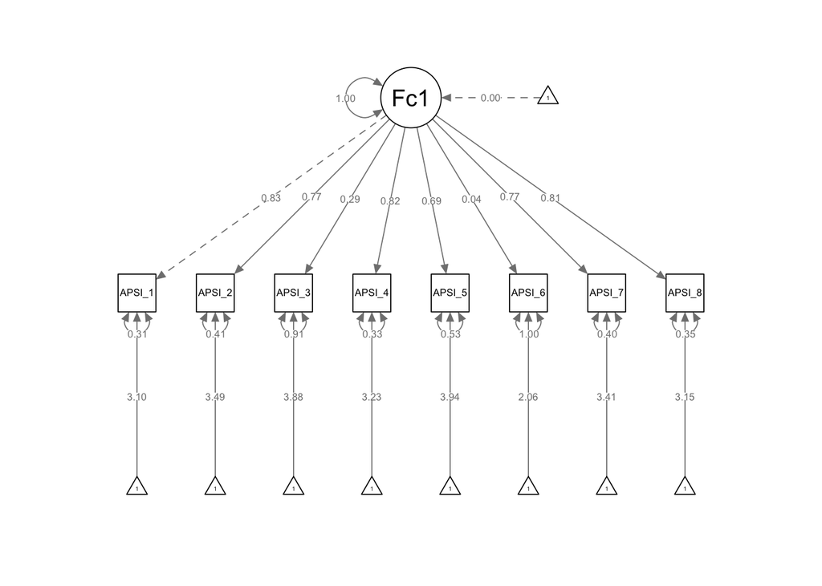

```r
semPaths(one.fit, whatLabels = "std", layout = "tree")
```

```r
summary(one.fit, standardized = TRUE, rsquare=TRUE)
```

```
## lavaan (0.5-20) converged normally after  22 iterations
##
##                                                   Used       Total
##   Number of observations                           935        1288
##
##   Number of missing patterns                         1
##
##   Estimator                                         ML
##   Minimum Function Test Statistic              316.884
##   Degrees of freedom                                20
##   P-value (Chi-square)                           0.000
##
## Parameter Estimates:
##
##   Information                                 Observed
##   Standard Errors                             Standard
##
## Latent Variables:
##                    Estimate  Std.Err  Z-value  P(>|z|)   Std.lv  Std.all
##   Factor1 =~
##     APSI_1            1.000                               0.999    0.831
##     APSI_2            0.860    0.032   27.122    0.000    0.859    0.771
##     APSI_3            0.293    0.034    8.733    0.000    0.293    0.294
##     APSI_4            0.972    0.034   28.927    0.000    0.970    0.819
##     APSI_5            0.722    0.031   23.001    0.000    0.721    0.687
##     APSI_6            0.054    0.048    1.135    0.257    0.054    0.039
##     APSI_7            0.878    0.033   26.533    0.000    0.877    0.774
##     APSI_8            0.976    0.035   28.262    0.000    0.975    0.807
##
## Intercepts:
##                    Estimate  Std.Err  Z-value  P(>|z|)   Std.lv  Std.all
##     APSI_1            3.720    0.039   94.639    0.000    3.720    3.095
##     APSI_2            3.889    0.036  106.645    0.000    3.889    3.488
##     APSI_3            3.865    0.033  118.698    0.000    3.865    3.882
##     APSI_4            3.828    0.039   98.761    0.000    3.828    3.230
##     APSI_5            4.135    0.034  120.517    0.000    4.135    3.941
##     APSI_6            2.876    0.046   63.003    0.000    2.876    2.060
##     APSI_7            3.863    0.037  104.249    0.000    3.863    3.409
##     APSI_8            3.811    0.040   96.421    0.000    3.811    3.153
##     Factor1           0.000                               0.000    0.000
```

[output cut: 8 more lines]

```
##     APSI_6            1.945    0.090   21.618    0.000    1.945    0.998
##     APSI_7            0.515    0.028   18.192    0.000    0.515    0.401
##     APSI_8            0.510    0.029   17.441    0.000    0.510    0.349
##     Factor1           0.998    0.066   15.151    0.000    1.000    1.000
##
## R-Square:
##                    Estimate
##     APSI_1            0.691
##     APSI_2            0.594
##     APSI_3            0.086
##     APSI_4            0.670
##     APSI_5            0.472
##     APSI_6            0.002
##     APSI_7            0.599
##     APSI_8            0.651
```

```r
correl1 = residuals(one.fit, type="cor")
correl1
```

```
## $type
## [1] "cor.bollen"
##
## $cor
##        APSI_1 APSI_2 APSI_3 APSI_4 APSI_5 APSI_6 APSI_7 APSI_8
## APSI_1  0.000
## APSI_2  0.046  0.000
## APSI_3 -0.035  0.002  0.000
## APSI_4 -0.007 -0.024 -0.026  0.000
## APSI_5  0.017  0.060  0.174 -0.034  0.000
## APSI_6 -0.005 -0.035 -0.266 -0.027  0.112  0.000
## APSI_7 -0.023 -0.059  0.027  0.040 -0.025  0.020  0.000
## APSI_8 -0.015 -0.011 -0.050  0.018 -0.038  0.020  0.042  0.000
##
## $mean
## APSI_1 APSI_2 APSI_3 APSI_4 APSI_5 APSI_6 APSI_7 APSI_8
##      0      0      0      0      0      0      0      0
```

```r
View(correl1$cor)
modindices(one.fit, sort. = TRUE, minimum.value = 3.84)
```

```
##       lhs op    rhs     mi    epc sepc.lv sepc.all sepc.nox
## 42 APSI_3 ~~ APSI_6 73.159 -0.373  -0.373   -0.268   -0.268
## 41 APSI_3 ~~ APSI_5 65.019  0.202   0.202    0.193    0.193
## 38 APSI_2 ~~ APSI_7 30.717 -0.114  -0.114   -0.091   -0.091
## 27 APSI_1 ~~ APSI_2 27.892  0.110   0.110    0.082    0.082
## 49 APSI_5 ~~ APSI_6 24.328  0.180   0.180    0.123    0.123
## 36 APSI_2 ~~ APSI_5 21.447  0.096   0.096    0.082    0.082
## 54 APSI_7 ~~ APSI_8 20.114  0.097   0.097    0.071    0.071
## 47 APSI_4 ~~ APSI_7 19.760  0.093   0.093    0.070    0.070
## 51 APSI_5 ~~ APSI_8 10.473 -0.070  -0.070   -0.055   -0.055
## 45 APSI_4 ~~ APSI_5  9.355 -0.064  -0.064   -0.051   -0.051
## 44 APSI_3 ~~ APSI_8  9.002 -0.074  -0.074   -0.062   -0.062
## 32 APSI_1 ~~ APSI_7  7.444 -0.058  -0.058   -0.042   -0.042
## 35 APSI_2 ~~ APSI_4  6.969 -0.055  -0.055   -0.041   -0.041
## 28 APSI_1 ~~ APSI_3  5.194 -0.054  -0.054   -0.045   -0.045
## 48 APSI_4 ~~ APSI_8  4.865  0.048   0.048    0.034    0.034
## 33 APSI_1 ~~ APSI_8  3.896 -0.044  -0.044   -0.030   -0.030
```

```r
fitmeasures(one.fit) #Models as a single purpose factor
```

```
##                npar                fmin               chisq
##              24.000               0.169             316.884
##                  df              pvalue      baseline.chisq
##              20.000               0.000            3568.378
##         baseline.df     baseline.pvalue                 cfi
##              28.000               0.000               0.916
##                 tli                nnfi                 rfi
##               0.883               0.883               0.876
##                 nfi                pnfi                 ifi
##               0.911               0.651               0.916
##                 rni                logl   unrestricted.logl
##               0.916          -10066.917           -9908.475
##                 aic                 bic              ntotal
##           20181.834           20298.007             935.000
##                bic2               rmsea      rmsea.ci.lower
##           20221.785               0.126               0.114
##      rmsea.ci.upper        rmsea.pvalue                 rmr
##               0.138               0.000               0.074
##          rmr_nomean                srmr        srmr_bentler
##               0.082               0.056               0.056
## srmr_bentler_nomean         srmr_bollen  srmr_bollen_nomean
##               0.062               0.056               0.062
##          srmr_mplus   srmr_mplus_nomean               cn_05
##               0.056               0.062              93.680
##               cn_01                 gfi                agfi
##             111.843               0.991               0.981
##                pgfi                 mfi                ecvi
##               0.451               0.853                  NA
```

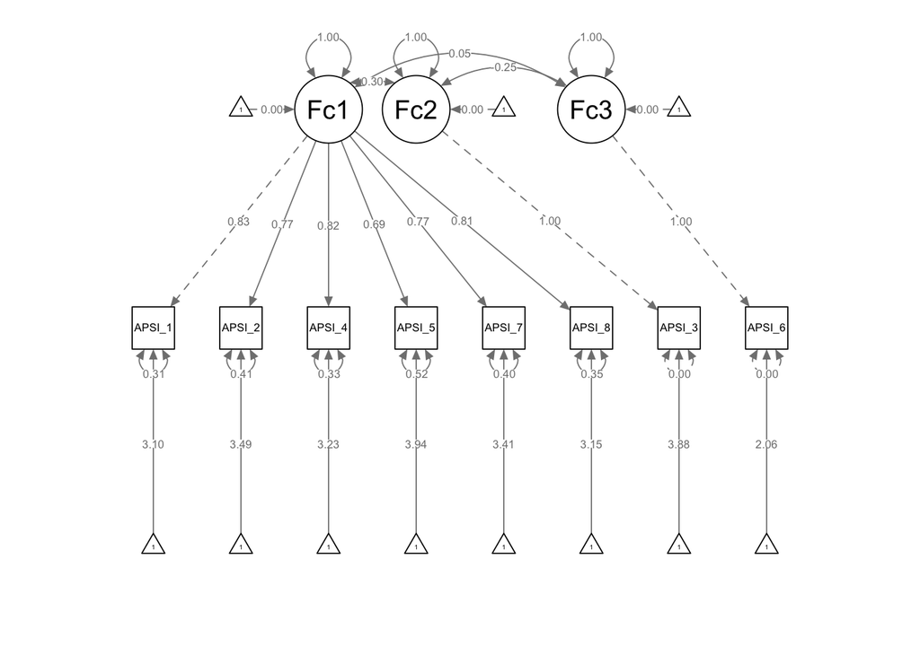

```r
data <- read.csv("~/Dropbox/Git/stats/allsurveysYT1_Jan2016.csv", header=T)
APSI<-select(data,  APSI_1, APSI_2, APSI_3, APSI_4, APSI_5, APSI_6, APSI_7, APSI_8)
one.model= ' Factor1  =~ APSI_1 + APSI_2 + APSI_4 + APSI_5 + APSI_7 + APSI_8
Factor 2 =~ APSI_3
Factor 3 =~ APSI_6'
one.fit=cfa(one.model, data=APSI, missing = "fiml")
semPaths(one.fit, whatLabels = "std", layout = "tree")
```

```r
summary(one.fit, standardized = TRUE, rsquare=TRUE)
```

```
## lavaan (0.5-20) converged normally after  39 iterations
##
##                                                   Used       Total
##   Number of observations                           935        1288
##
##   Number of missing patterns                         1
##
##   Estimator                                         ML
##   Minimum Function Test Statistic              240.621
##   Degrees of freedom                                19
##   P-value (Chi-square)                           0.000
##
## Parameter Estimates:
##
##   Information                                 Observed
##   Standard Errors                             Standard
##
## Latent Variables:
##                    Estimate  Std.Err  Z-value  P(>|z|)   Std.lv  Std.all
##   Factor1 =~
##     APSI_1            1.000                               0.998    0.831
##     APSI_2            0.860    0.032   27.083    0.000    0.859    0.770
##     APSI_4            0.971    0.034   28.883    0.000    0.969    0.818
##     APSI_5            0.725    0.031   23.076    0.000    0.723    0.690
##     APSI_7            0.879    0.033   26.536    0.000    0.877    0.774
##     APSI_8            0.977    0.035   28.244    0.000    0.975    0.807
##   Factor2 =~
##     APSI_3            1.000                               0.996    1.000
##   Factor3 =~
##     APSI_6            1.000                               1.396    1.000
##
## Covariances:
##                    Estimate  Std.Err  Z-value  P(>|z|)   Std.lv  Std.all
##   Factor1 ~~
##     Factor2           0.294    0.036    8.166    0.000    0.295    0.295
##     Factor3           0.066    0.048    1.388    0.165    0.048    0.048
##   Factor2 ~~
##     Factor3          -0.354    0.047   -7.540    0.000   -0.254   -0.254
##
## Intercepts:
```

[output cut: 22 more lines]

```
##     APSI_6            0.000                               0.000    0.000
##     Factor1           0.997    0.066   15.139    0.000    1.000    1.000
##     Factor2           0.991    0.046   21.622    0.000    1.000    1.000
##     Factor3           1.948    0.090   21.622    0.000    1.000    1.000
##
## R-Square:
##                    Estimate
##     APSI_1            0.690
##     APSI_2            0.593
##     APSI_4            0.669
##     APSI_5            0.476
##     APSI_7            0.599
##     APSI_8            0.651
##     APSI_3            1.000
##     APSI_6            1.000
```

```r
correl1 = residuals(one.fit, type="cor")
correl1
```

```
## $type
## [1] "cor.bollen"
##
## $cor
##        APSI_1 APSI_2 APSI_4 APSI_5 APSI_7 APSI_8 APSI_3 APSI_6
## APSI_1  0.000
## APSI_2  0.046  0.000
## APSI_4 -0.006 -0.023  0.000
## APSI_5  0.015  0.059 -0.035  0.000
## APSI_7 -0.023 -0.059  0.041 -0.027  0.000
## APSI_8 -0.014 -0.011  0.018 -0.039  0.042  0.000
## APSI_3 -0.036  0.001 -0.027  0.172  0.026 -0.051  0.000
## APSI_6 -0.012 -0.041 -0.034  0.106  0.013  0.013  0.000  0.000
##
## $mean
## APSI_1 APSI_2 APSI_4 APSI_5 APSI_7 APSI_8 APSI_3 APSI_6
##      0      0      0      0      0      0      0      0
```

```r
View(correl1$cor)
correl2 = residuals(one.fit, type="standardized")
correl2$cov
```

```
##        APSI_1 APSI_2 APSI_4 APSI_5 APSI_7 APSI_8 APSI_3 APSI_6
## APSI_1     NA
## APSI_2  4.285     NA
## APSI_4 -0.888 -2.953  0.000
## APSI_5  1.402  3.972 -3.735  0.000
## APSI_7 -3.285 -7.773  3.710 -2.305     NA
## APSI_8 -2.201 -1.199  2.064 -4.003  3.726  0.000
## APSI_3 -2.435  0.042 -1.714  7.314  1.422 -3.192     NA
## APSI_6 -0.745 -2.162 -2.025  4.604  0.692  0.741  0.000  0.000
```

```r
View(correl2$cov)
modindices(one.fit, sort. = TRUE, minimum.value = 3.84)
```

```
##        lhs op    rhs     mi    epc sepc.lv sepc.all sepc.nox
## 70  APSI_5 ~~ APSI_3 95.097  0.234   0.234    0.224    0.224
## 39 Factor2 =~ APSI_5 64.355  0.221   0.220    0.210    0.210
## 71  APSI_5 ~~ APSI_6 52.222  0.252   0.252    0.172    0.172
## 59  APSI_2 ~~ APSI_7 30.503 -0.114  -0.114   -0.090   -0.090
## 50  APSI_1 ~~ APSI_2 28.642  0.111   0.111    0.083    0.083
## 46 Factor3 =~ APSI_5 21.928  0.088   0.122    0.116    0.116
## 58  APSI_2 ~~ APSI_5 20.544  0.094   0.094    0.080    0.080
## 64  APSI_4 ~~ APSI_7 19.996  0.094   0.094    0.070    0.070
## 72  APSI_7 ~~ APSI_8 19.987  0.097   0.097    0.071    0.071
## 69  APSI_5 ~~ APSI_8 11.554 -0.073  -0.073   -0.058   -0.058
## 63  APSI_4 ~~ APSI_5 10.133 -0.066  -0.066   -0.053   -0.053
## 41 Factor2 =~ APSI_8  9.390 -0.084  -0.084   -0.069   -0.069
## 75  APSI_8 ~~ APSI_3  8.872 -0.071  -0.071   -0.059   -0.059
## 53  APSI_1 ~~ APSI_7  7.358 -0.057  -0.057   -0.042   -0.042
## 55  APSI_1 ~~ APSI_3  7.095 -0.061  -0.061   -0.051   -0.051
## 67  APSI_4 ~~ APSI_6  6.717 -0.087  -0.087   -0.052   -0.052
## 57  APSI_2 ~~ APSI_4  6.306 -0.052  -0.052   -0.039   -0.039
## 36 Factor2 =~ APSI_1  5.483 -0.062  -0.061   -0.051   -0.051
## 66  APSI_4 ~~ APSI_3  5.468 -0.054  -0.054   -0.046   -0.046
## 65  APSI_4 ~~ APSI_8  5.256  0.050   0.050    0.035    0.035
## 62  APSI_2 ~~ APSI_6  5.006 -0.075  -0.075   -0.048   -0.048
## 44 Factor3 =~ APSI_2  4.648 -0.039  -0.054   -0.049   -0.049
## 68  APSI_5 ~~ APSI_7  4.472 -0.044  -0.044   -0.037   -0.037
## 45 Factor3 =~ APSI_4  4.070 -0.036  -0.050   -0.043   -0.043
```

```r
summary(one.fit)
```

```
## lavaan (0.5-20) converged normally after  39 iterations
##
##                                                   Used       Total
##   Number of observations                           935        1288
##
##   Number of missing patterns                         1
##
##   Estimator                                         ML
##   Minimum Function Test Statistic              240.621
##   Degrees of freedom                                19
##   P-value (Chi-square)                           0.000
##
## Parameter Estimates:
##
##   Information                                 Observed
##   Standard Errors                             Standard
##
## Latent Variables:
##                    Estimate  Std.Err  Z-value  P(>|z|)
##   Factor1 =~
##     APSI_1            1.000
##     APSI_2            0.860    0.032   27.083    0.000
##     APSI_4            0.971    0.034   28.883    0.000
##     APSI_5            0.725    0.031   23.076    0.000
##     APSI_7            0.879    0.033   26.536    0.000
##     APSI_8            0.977    0.035   28.244    0.000
##   Factor2 =~
##     APSI_3            1.000
##   Factor3 =~
##     APSI_6            1.000
##
## Covariances:
##                    Estimate  Std.Err  Z-value  P(>|z|)
##   Factor1 ~~
##     Factor2           0.294    0.036    8.166    0.000
##     Factor3           0.066    0.048    1.388    0.165
##   Factor2 ~~
##     Factor3          -0.354    0.047   -7.540    0.000
##
## Intercepts:
```

[output cut: 11 more lines]

```
##     Factor3           0.000
##
## Variances:
##                    Estimate  Std.Err  Z-value  P(>|z|)
##     APSI_1            0.448    0.027   16.592    0.000
##     APSI_2            0.506    0.028   18.258    0.000
##     APSI_4            0.465    0.027   17.095    0.000
##     APSI_5            0.577    0.030   19.537    0.000
##     APSI_7            0.515    0.028   18.187    0.000
##     APSI_8            0.510    0.029   17.451    0.000
##     APSI_3            0.000
##     APSI_6            0.000
##     Factor1           0.997    0.066   15.139    0.000
##     Factor2           0.991    0.046   21.622    0.000
##     Factor3           1.948    0.090   21.622    0.000
```

```r
fitmeasures(one.fit) #Models as a single purpose factor
```

```
##                npar                fmin               chisq
##              25.000               0.129             240.621
##                  df              pvalue      baseline.chisq
##              19.000               0.000            3568.378
##         baseline.df     baseline.pvalue                 cfi
##              28.000               0.000               0.937
##                 tli                nnfi                 rfi
##               0.908               0.908               0.901
##                 nfi                pnfi                 ifi
##               0.933               0.633               0.938
##                 rni                logl   unrestricted.logl
##               0.937          -10028.786           -9908.475
##                 aic                 bic              ntotal
##           20107.571           20228.585             935.000
##                bic2               rmsea      rmsea.ci.lower
##           20149.187               0.112               0.099
##      rmsea.ci.upper        rmsea.pvalue                 rmr
##               0.125               0.000               0.048
##          rmr_nomean                srmr        srmr_bentler
##               0.053               0.039               0.039
## srmr_bentler_nomean         srmr_bollen  srmr_bollen_nomean
##               0.043               0.039               0.043
##          srmr_mplus   srmr_mplus_nomean               cn_05
##               0.039               0.043             118.131
##               cn_01                 gfi                agfi
##             141.630               0.993               0.985
##                pgfi                 mfi                ecvi
##               0.429               0.888                  NA
```

```r
inspect(one.fit,what="std")
```

```
## $lambda
##        Factr1 Factr2 Factr3
## APSI_1  0.831      0      0
## APSI_2  0.770      0      0
## APSI_4  0.818      0      0
## APSI_5  0.690      0      0
## APSI_7  0.774      0      0
## APSI_8  0.807      0      0
## APSI_3  0.000      1      0
## APSI_6  0.000      0      1
##
## $theta
##        APSI_1 APSI_2 APSI_4 APSI_5 APSI_7 APSI_8 APSI_3 APSI_6
## APSI_1 0.310
## APSI_2 0.000  0.407
## APSI_4 0.000  0.000  0.331
## APSI_5 0.000  0.000  0.000  0.524
## APSI_7 0.000  0.000  0.000  0.000  0.401
## APSI_8 0.000  0.000  0.000  0.000  0.000  0.349
## APSI_3 0.000  0.000  0.000  0.000  0.000  0.000  0.000
## APSI_6 0.000  0.000  0.000  0.000  0.000  0.000  0.000  0.000
##
## $psi
##         Factr1 Factr2 Factr3
## Factor1  1.000
## Factor2  0.295  1.000
## Factor3  0.048 -0.254  1.000
##
## $nu
##        intrcp
## APSI_1  3.095
## APSI_2  3.488
## APSI_4  3.230
## APSI_5  3.941
## APSI_7  3.409
## APSI_8  3.153
## APSI_3  3.882
## APSI_6  2.060
##
## $alpha
##         intrcp
## Factor1      0
## Factor2      0
## Factor3      0
```

```r
fitted(one.fit)
```

```
## $cov
##        APSI_1 APSI_2 APSI_4 APSI_5 APSI_7 APSI_8 APSI_3 APSI_6
## APSI_1  1.444
## APSI_2  0.857  1.243
## APSI_4  0.968  0.833  1.405
## APSI_5  0.722  0.621  0.701  1.101
## APSI_7  0.876  0.753  0.850  0.635  1.284
## APSI_8  0.973  0.837  0.945  0.705  0.855  1.460
## APSI_3  0.294  0.253  0.285  0.213  0.258  0.287  0.991
## APSI_6  0.066  0.057  0.065  0.048  0.058  0.065 -0.354  1.948
##
## $mean
## APSI_1 APSI_2 APSI_4 APSI_5 APSI_7 APSI_8 APSI_3 APSI_6
##  3.720  3.889  3.828  4.135  3.863  3.811  3.865  2.876
```

```r
cov2cor(inspect(one.fit, "coefficients")$psi)
```

```
##         Factr1 Factr2 Factr3
## Factor1  1.000
## Factor2  0.295  1.000
## Factor3  0.048 -0.254  1.000
```

```r
 #Models two factors:Positive and Negative
```

Misc code for exportign tabel

```r
#fa.results(out_targetQ)
#xtable(out_targetQ)

#source("http://bioconductor.org/biocLite.R")
#biocLite(c("graph", "RBGL", "Rgraphviz"))
#library(Rgraphviz)
#library(schoRsch)
#library(xtable)
#library(knitr)
#library(devtools)

#fa2latex(fa(APSI,1,rotate="oblimin", fm="ml"),heading="Table 1. Factor analysis OF APSI as One Factor")
```